# STA100 Lab3

Chi Po Choi

10/14/2021

# Exercise in `Discussion_03.pdf`

Get the `Discussion_03.pdf` prepared by Maxime in [STA100B Piazza Resources](https://piazza.com/ucdavis/fall2021/sta100b/resources) .

# Quick start with R and RStudio again!

#### Working directory

Working directory is the default folder in which files are saved and read.

- In the **Files** tab, find/create a folder for your STA100 work. Click **More** then click **Set As Working Directory**.
- Download the `ErinsFitbit2016.csv` in [STA100B Piazza Resources](https://piazza.com/ucdavis/fall2021/sta100b/resources) and save it into your working directory. Then, run the codes `erins_fitbit = read.csv("ErinsFitbit2016.csv")`
- Click on the Data `erins_fitbit` in Environment tab. You see what is inside `erins_fitbit`.

#### R scripts

- Click the “little green plus icon” and select **R Script**. Then you obtain a notebook that for your to put R codes. Type some codes, for example

  ```r
  erins_fitbit = read.csv("ErinsFitbit2016.csv", stringsAsFactors = TRUE)
  qqnorm(erins_fitbit$Sleep)
  qqline(erins_fitbit$Sleep)
  ```

- You can also **Run** line by line. Put your cursor to the line your want to run and click **Run**. You can also use hot-key **Command+Enter** in mac (or **Control+Enter** in Windows?).
- Click the floppy icon to save your R script in your working directory. Usually we save R scripts with file extension `.R`, for example, `lab3_is_great.R`.

#### Book Problems

Let’s work on some the problems during the Lab.

- Q1 12:15pm-12:25pm

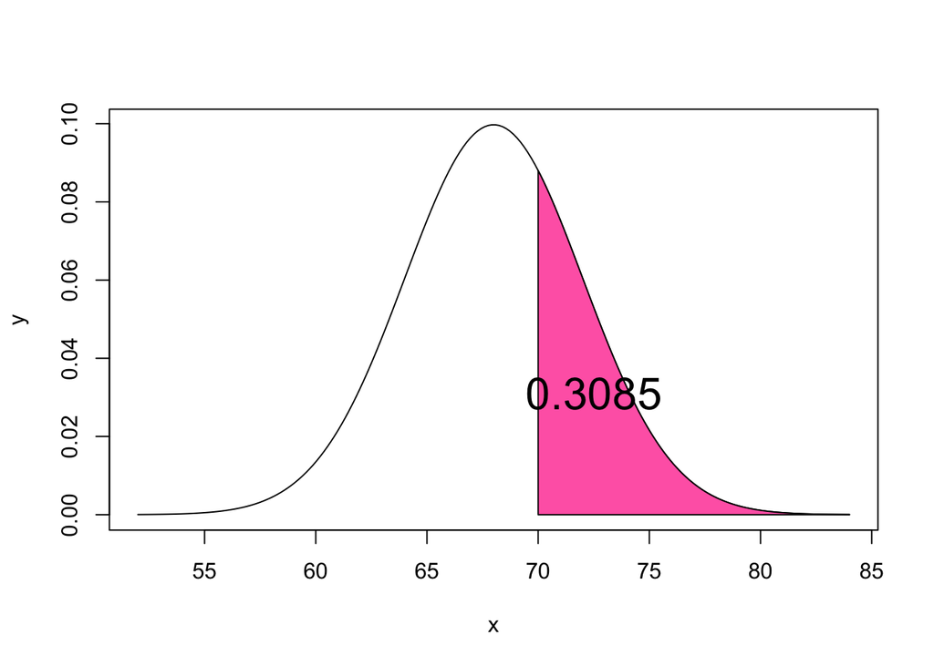

```r
plot_z_area = function(lower_boundary,
                       upper_boundary,
                       my_mean = 0,
                       my_sd = 1,
                       my_col = "hotpink",
                       text_col = "black") {

  lower_boundary = max(lower_boundary, my_mean-4*my_sd)
  upper_boundary = min(upper_boundary, my_mean+4*my_sd)
  x = seq(my_mean-4*my_sd, my_mean+4*my_sd, length=200)
  y = dnorm(x, mean=my_mean, sd=my_sd)
  plot(x, y, type="l")

  p_x = seq(lower_boundary, upper_boundary, length=100)
  p_y = dnorm(p_x, mean=my_mean, sd=my_sd)
  polygon(c(lower_boundary, p_x, upper_boundary), c(0, p_y, 0), col=my_col)

  p = pnorm(c(lower_boundary, upper_boundary), mean=my_mean, sd=my_sd)
  text(sum(p_x*p_y)/sum(p_y), mean(y), sprintf("%.4f", p[2]-p[1]),
       col = text_col, cex = 2)
}

plot_z_area(70, 100, my_mean = 68, my_sd = 4)
```

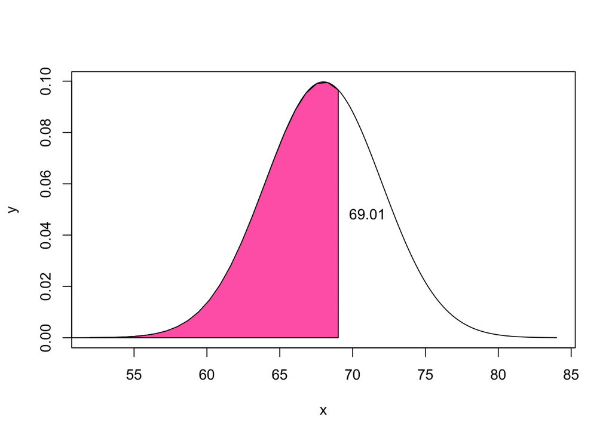

```r
plot_z_area_percentile = function(percentile,
                       my_mean = 0,
                       my_sd = 1,
                       my_col = "hotpink",
                       text_col = "black") {

  lower_boundary = -4
  upper_boundary = qnorm(percentile, mean=my_mean, sd=my_sd)
  x = seq(my_mean-4*my_sd, my_mean+4*my_sd, length=200)
  y = dnorm(x, mean=my_mean, sd=my_sd)
  plot(x, y, type="l")

  p_x = seq(lower_boundary, upper_boundary, length=100)
  p_y = dnorm(p_x, mean=my_mean, sd=my_sd)
  polygon(c(lower_boundary, p_x, upper_boundary), c(0, p_y, 0), col=my_col)

  p = pnorm(c(lower_boundary, upper_boundary), mean=my_mean, sd=my_sd)
  text(upper_boundary+0.5*my_sd, p_y[100]/2, sprintf("%.2f", upper_boundary),
       col = text_col, cex = 1)
}

plot_z_area_percentile(0.6, my_mean = 68, my_sd = 4)
```

- Q2 12:35pm-12:45pm

#### R Portion

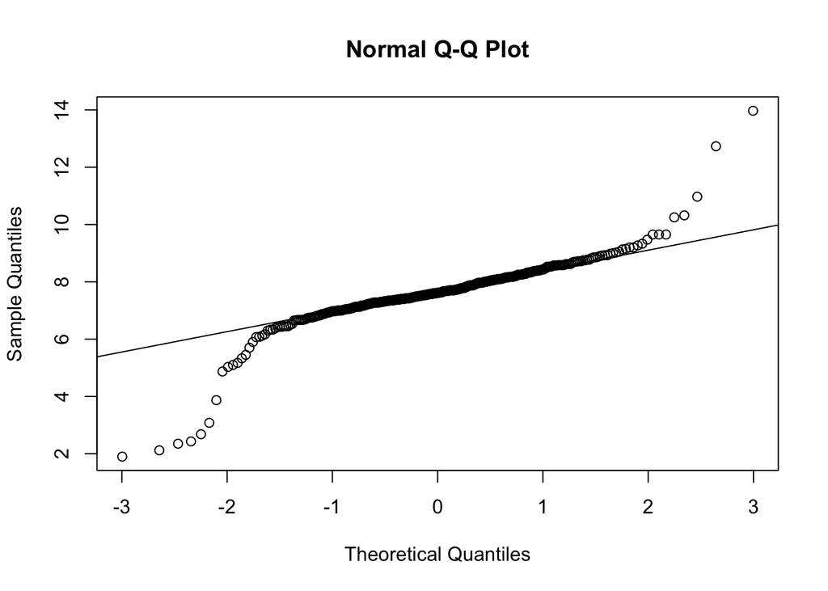

```r
erins_fitbit = read.csv("ErinsFitbit2016.csv")

#R Problem 1, (a)
qqnorm(erins_fitbit$Sleep)
qqline(erins_fitbit$Sleep)
```

```r
#R Problem 1, (b)
x = erins_fitbit$Sleep

mean_x = mean(x)
sd_x = sd(x)

mean_x
```

```
## [1] 7.612268
```

```r
sd_x
```

```
## [1] 1.144888
```

```r
erins_fitbit$flag_inside_1_sd = abs(x - mean_x) < sd_x
erins_fitbit$flag_inside_2_sd = abs(x - mean_x) < 2*sd_x
erins_fitbit$flag_inside_3_sd = abs(x - mean_x) < 3*sd_x

knitr::kable(
  head(erins_fitbit)
)
```

| Month | Day | Steps | Miles | Floors | Sed | Active | Sleep | flag_inside_1_sd | flag_inside_2_sd | flag_inside_3_sd |
| --- | --- | --- | --- | --- | --- | --- | --- | --- | --- | --- |
| Jan | Fri | 7345 | 3.21 | 31 | 9.75 | 5.47 | 7.97 | TRUE | TRUE | TRUE |
| Jan | Sat | 114 | 0.05 | 1 | 14.68 | 0.15 | 8.53 | TRUE | TRUE | TRUE |
| Jan | Sun | 15400 | 6.73 | 37 | 7.93 | 6.50 | 7.38 | TRUE | TRUE | TRUE |
| Jan | Mon | 10781 | 5.01 | 39 | 10.97 | 5.68 | 7.00 | TRUE | TRUE | TRUE |
| Jan | Tue | 13773 | 6.13 | 12 | 9.27 | 4.45 | 9.33 | FALSE | TRUE | TRUE |
| Jan | Wed | 11512 | 5.16 | 31 | 10.62 | 5.45 | 7.03 | TRUE | TRUE | TRUE |

```r
sum(erins_fitbit$flag_inside_1_sd)/length(erins_fitbit$flag_inside_1_sd)
```

```
## [1] 0.8415301
```

```r
mean(erins_fitbit$flag_inside_1_sd)
```

```
## [1] 0.8415301
```

```r
mean(erins_fitbit$flag_inside_2_sd)
```

```
## [1] 0.9562842
```

```r
mean(erins_fitbit$flag_inside_3_sd)
```

```
## [1] 0.9754098
```